# 624: ARIMA

Sean Connin

03/11/22

```r
library(fpp3)
library(magrittr)
library(tidyverse)
library(patchwork)
library(fable)
library(flextable)
```

# 1 Hyndman: Exercise 9.1

Figure 9.32 shows the ACFs for 36 random numbers, 360 random numbers and 1,000 random numbers.

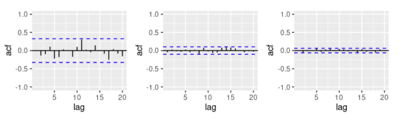

Figure 9.32

**Explain the differences among these figures. Do they all indicate that the data are white noise?**

*Each of the ACF plots is demonstrative of a ‘white noise’ signal - i.e., the mean of the residuals is ~ zero and there are no indications of autocorrelation within the datasets.*

**Why are the critical values at different distances from the mean of zero? Why are the autocorrelations different in each figure when they each refer to white noise?**

*The Y-axis on an ACF plot spans from -1 to 1 and reflects a range of possible correlation coefficients associated with the lag values. The dashed horizontal lines (critical values) indicate the statistical threshold for significance. These values decrease as the number of observations increase and the correlation estimates stabilize (i.e., residual errors decrease).*

# 2 Hyndman: Exercise 9.2

**A classic example of a non-stationary series are stock prices. Plot the daily closing prices for Amazon stock (contained in gafa_stock), along with the ACF and PACF. Explain how each plot shows that the series is non-stationary and should be differenced.**

*Figure 1. AMZN’s closing stock time series increases over time with possible seasonal adjustments (intra-annual). These features are obvious signatures of nonstationarity.*

*Figure 2. The ACF plot highlights significant autocorrelation at all lags, indicating non-stationarity.*

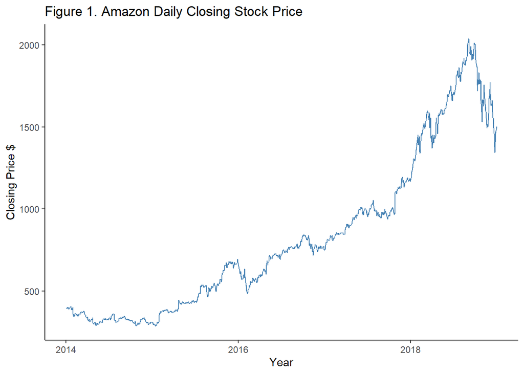

```r
#subset data

amzn<-gafa_stock%>%
  filter(Symbol %in% 'AMZN')%>%
  select(Symbol, Date, Close)

# plot time series

amzn%>%
  autoplot(color = 'steelblue')+
  labs(title= 'Figure 1. Amazon Daily Closing Stock Price', x = 'Year', y='Closing Price $')+
  theme_classic()
```

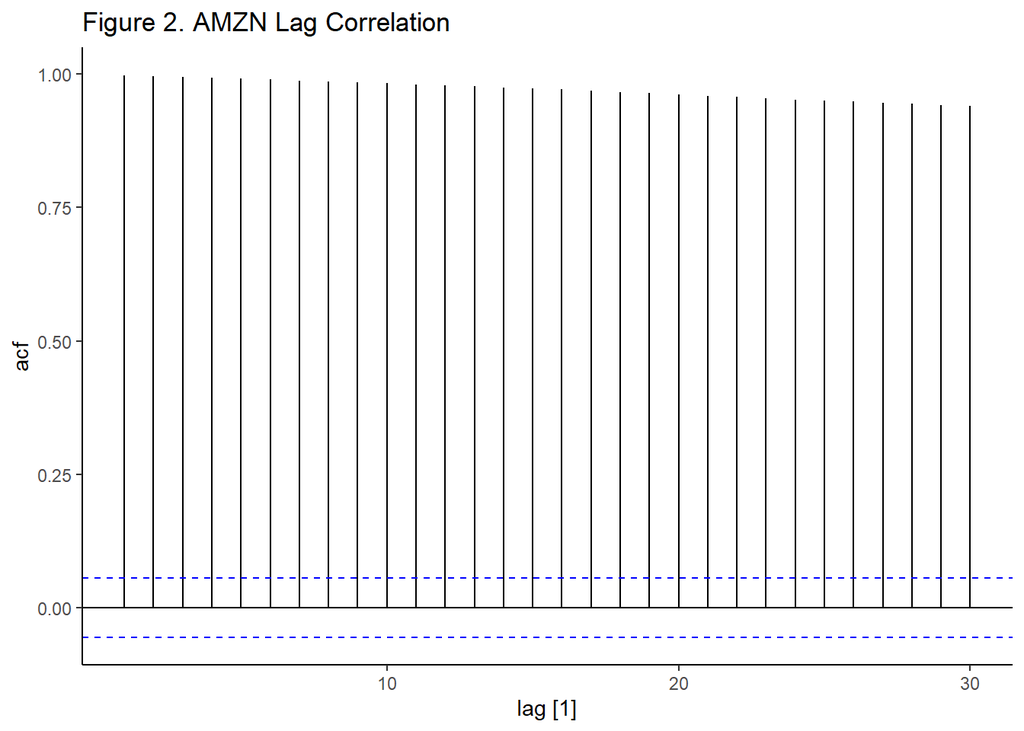

```r
#amzn %>%
  #features(Close, feat_acf)

# plot acf

  ACF(amzn, type='correlation') %>%
  autoplot(color = 'steelblue') +
  labs(title = "Figure 2. AMZN Lag Correlation")+
  theme_classic()
```

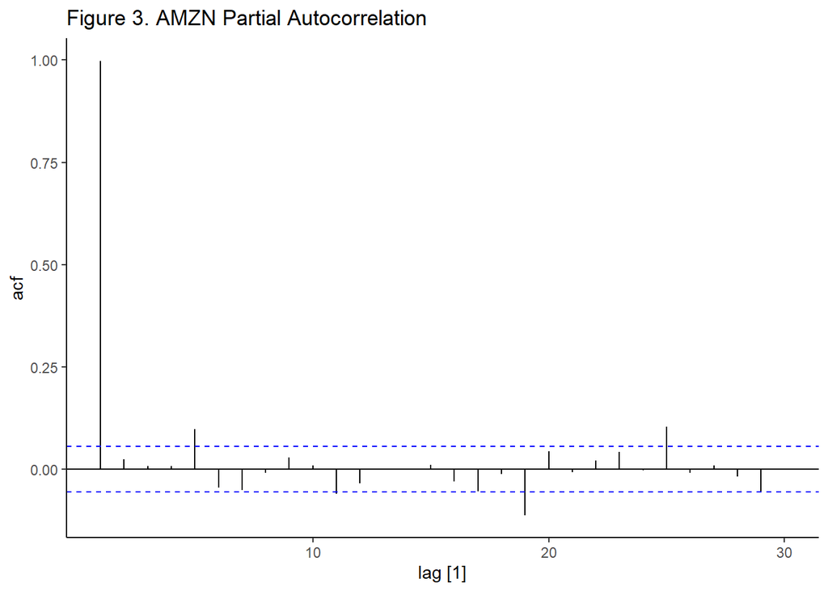

```r
  # plot pacf

ACF(amzn, type='partial') %>%
  autoplot(color = 'steelblue') +
  labs(title = "Figure 3. AMZN Partial Autocorrelation")+
  theme_classic()
```

# 3 Hyndman: Exercise 9.3

**For the following series, find an appropriate Box-Cox transformation and order of differencing in order to obtain stationary data.**

**Turkish GDP from global_economy.**

*The box_cox lambda value for Turkish GDP was 0.15 which points to a log transformation.*

*Results of unitroot tests indicate that first order differencing with lambda transformation (kpss_stat = 0.08888563, kpss_pvalue=0.1) results in a stationary dataset.*

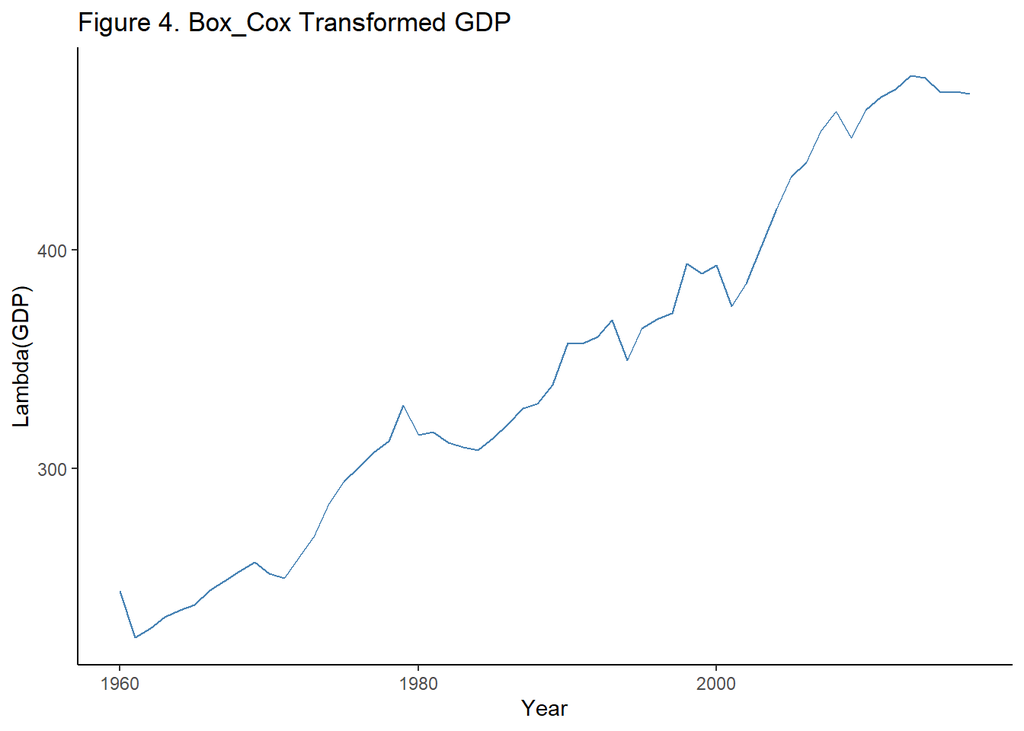

```r
# subset the data

turkey<-global_economy%>%
  filter(Country %in% 'Turkey')%>%
  select(GDP)

#ACF(turkey)%>%autoplot() -- there are significant lags up to lag 10, gradual decline

# Estimate lambda

lambda<-turkey%>%
  features(GDP, features=guerrero)%>%
  pull(lambda_guerrero)

# Plot transformed data

turkey%>%
  autoplot(box_cox(GDP, lambda), color='steelblue')+
  labs(title = 'Figure 4. Box_Cox Transformed GDP', x= 'Year', y='Lambda(GDP)')+
  theme_classic()
```

```r
# Apply unit root test

turkey %>%
  mutate(GDP_1Diff = difference(box_cox(GDP, lambda)))%>%
  features(GDP_1Diff, unitroot_kpss)%>%
  flextable()%>%
  set_caption('Table 1. Unit Root Test: Turkey GDP - Single Differencing')
```

Table 1. Unit Root Test: Turkey GDP - Single Differencing

| kpss_stat | kpss_pvalue |
| --- | --- |
| 0.08888563 | 0.1 |

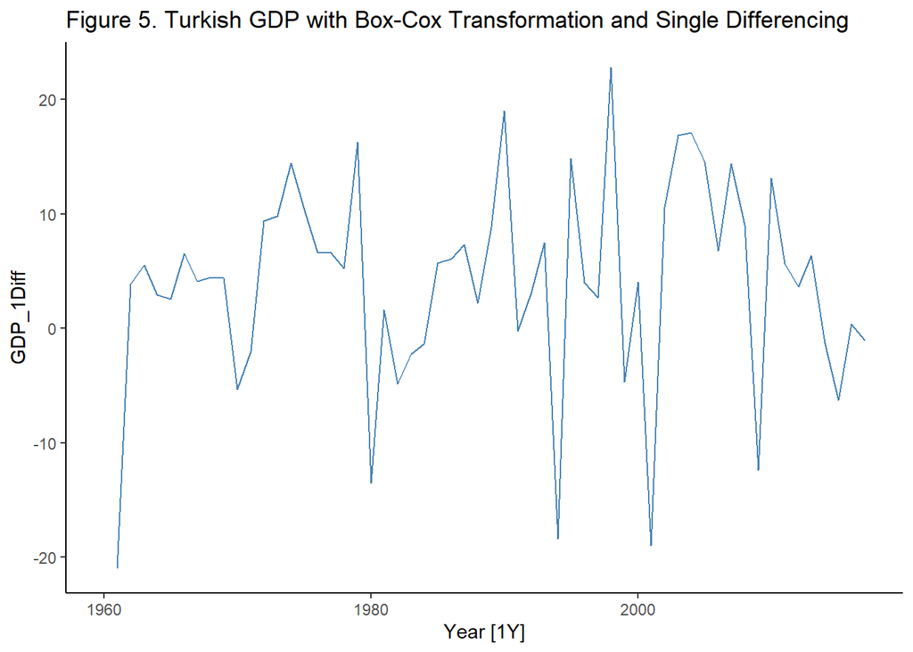

```r
#plot 1st order differencing

turkey%>%
  mutate(GDP_1Diff = difference(box_cox(GDP, lambda)))%>%
  autoplot(GDP_1Diff, color='steelblue')+
  labs(title = 'Figure 5. Turkish GDP with Box-Cox Transformation and Single Differencing')+
  theme_classic()
```

**Accommodation takings in the state of Tasmania from aus_accommodation.**

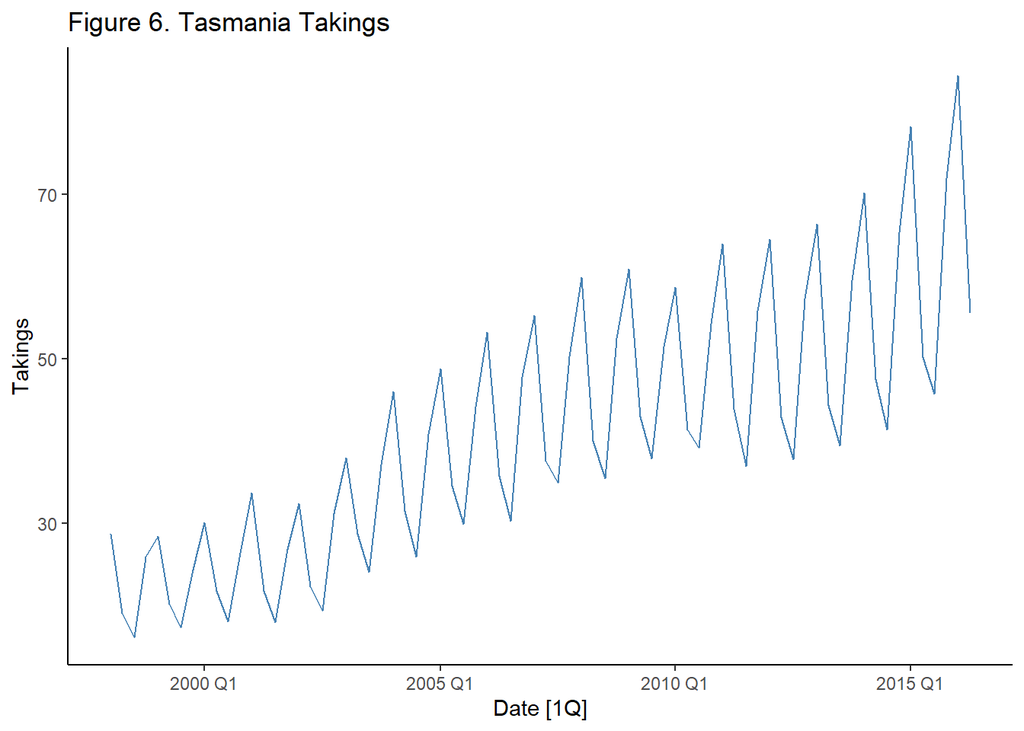

```r
# subset the data


accom<-aus_accommodation%>%
  filter(State %in% 'Tasmania')%>%
  select(Takings)

#plot data

accom%>%
 autoplot(Takings, color='steelblue')+
  labs(title = 'Figure 6. Tasmania Takings')+
  theme_classic()
```

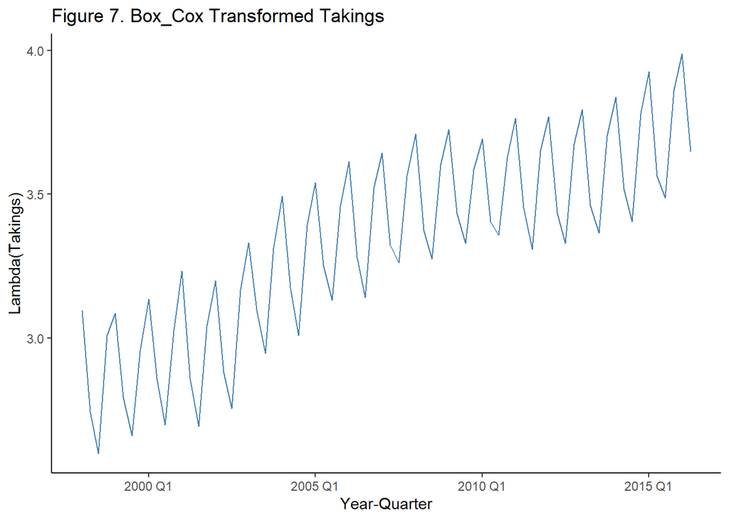

```r
# Estimate lambda

lambda_accom<-accom%>%
  features(Takings, features=guerrero)%>%
  pull(lambda_guerrero)

# Plot transformed data

accom%>%
  autoplot(box_cox(Takings, lambda_accom), color='steelblue')+
  labs(title = 'Figure 7. Box_Cox Transformed Takings', x= 'Year-Quarter', y='Lambda(Takings)')+
  theme_classic()
```

```r
# Apply unit root test

#accom %>% features((box_cox(Takings, lambda_accom)), unitroot_nsdiffs) # 1 diff indicated

accom %>%
  mutate(Takings_1Diff = difference(box_cox(Takings, lambda_accom)), 4)%>%   # apply seasonal differencing
  features(Takings_1Diff, unitroot_kpss)%>%  # evaluated ndiffs - none required
  flextable()%>%
  set_caption('Table 2. Unit Root Test: Tasmania Takings - Single Seasonal Differencing')
```

| kpss_stat | kpss_pvalue |
| --- | --- |
| 0.2557541 | 0.1 |

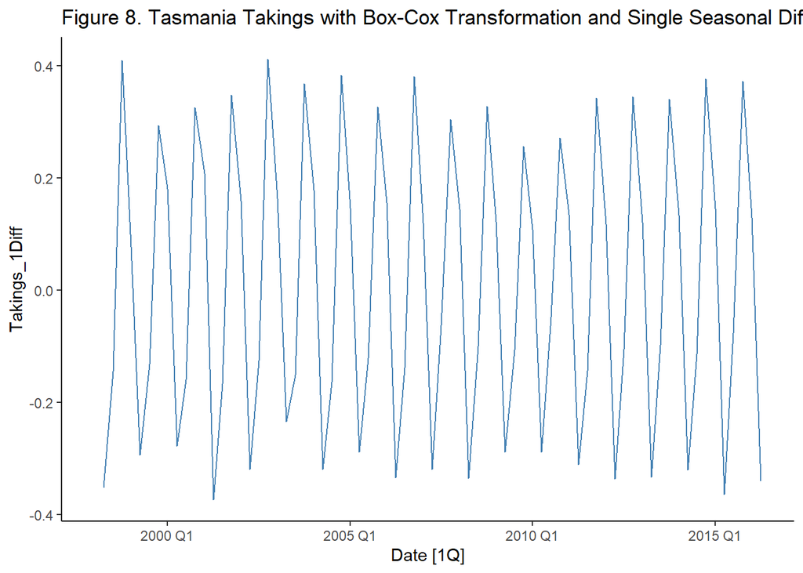

```r
#plot 1st order differencing

accom%>%
  mutate(Takings_1Diff = difference(box_cox(Takings, lambda_accom)))%>%
  autoplot(Takings_1Diff, color='steelblue')+
  labs(title = 'Figure 8. Tasmania Takings with Box-Cox Transformation and Single Seasonal Differencing')+
  theme_classic()
```

**Monthly sales from souvenirs.**

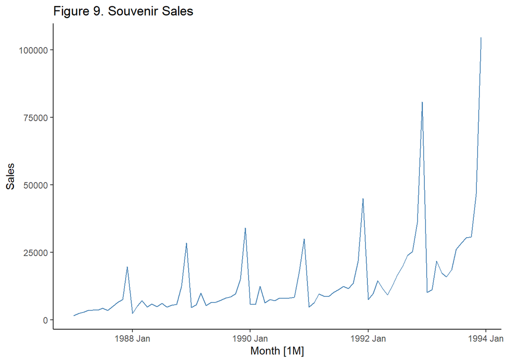

```r
#souvenirs # there is clear monthly seasonality in this dataset (not shown here)


#plot untransformed data

souvenirs%>%
 autoplot(Sales, color='steelblue')+
  labs(title = 'Figure 9. Souvenir Sales')+
  theme_classic()
```

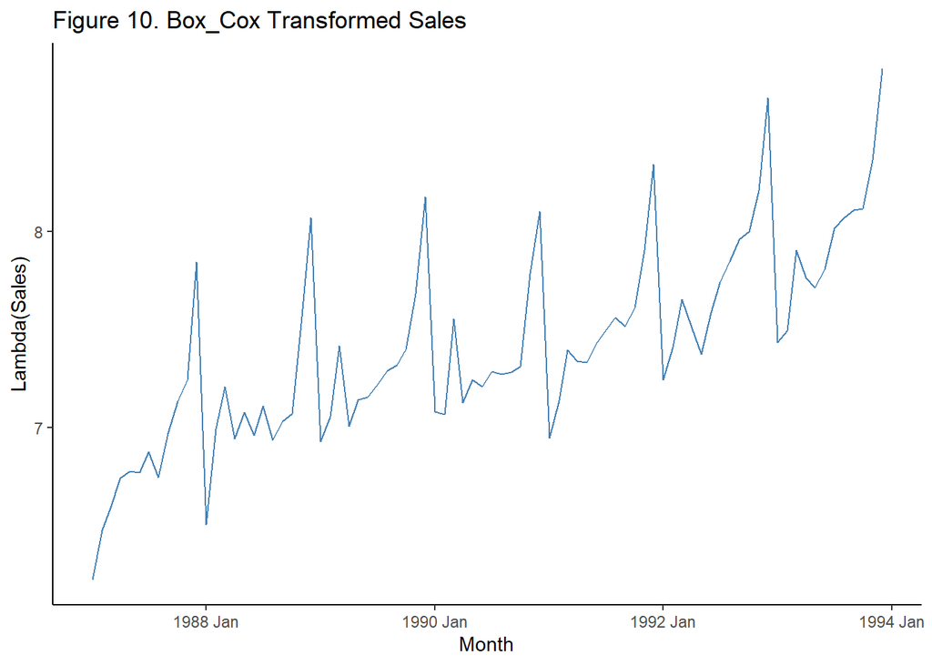

```r
# Estimate lambda

lambda_sales<-souvenirs%>%
  features(Sales, features=guerrero)%>%
  pull(lambda_guerrero)

# Plot transformed data

souvenirs%>%
  autoplot(box_cox(Sales, lambda_accom), color='steelblue')+
  labs(title = 'Figure 10. Box_Cox Transformed Sales', x= 'Month', y='Lambda(Sales)')+
  theme_classic()
```

```r
# Apply unit root test

#souvenirs %>% features((box_cox(Sales, lambda_accom)), unitroot_nsdiffs) # 1 seasonal diff indicated

souvenirs %>%
  mutate(Sales_1Diff = difference(box_cox(Sales, lambda_sales)), 12)%>%
  features(Sales_1Diff, unitroot_nsdiffs)%>%
  flextable()%>%
  set_caption('Table 3. Unit Root Test: Souvenirs Sales - Single Seasonal Differencing')
```

| nsdiffs |
| --- |
| 1 |

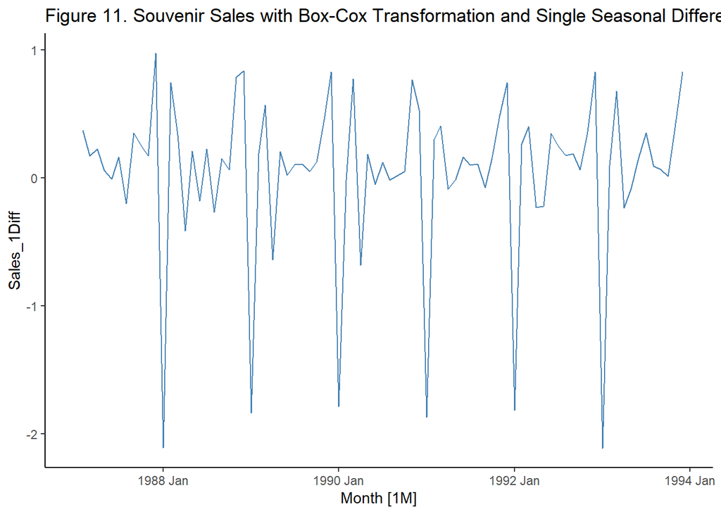

```r
#plot 1st order differencing

souvenirs%>%
  mutate(Sales_1Diff = difference(box_cox(Sales, lambda_sales)))%>%
  autoplot(Sales_1Diff , color='steelblue')+
  labs(title = 'Figure 11. Souvenir Sales with Box-Cox Transformation and Single Seasonal Differencing')+
  theme_classic()
```

# 4 Hyndman: Exercise 9.3

**For your retail data (from Exercise 8 in Section 2.10), find the appropriate order of differencing (after transformation if necessary) to obtain stationary data.**

*There are is a clear upward trend, seasonal signal, and nonconstant variance in the Industry turnover data (Figure 12).*

*A log transformation on Turnover was applied to reduce heteroskedasticity (Figure 13).*

*STL decomposition was applied to extract a seasonally adjusted series (Figure 14). There does appear to be some grouping patterns in the remainder.*

*An ACF plot of the differenced data (stationary) indicates continuing issues with lag autocorrelation (Figure 16). These were minimized using a 5 year seasonal window in the STL decomposition.*

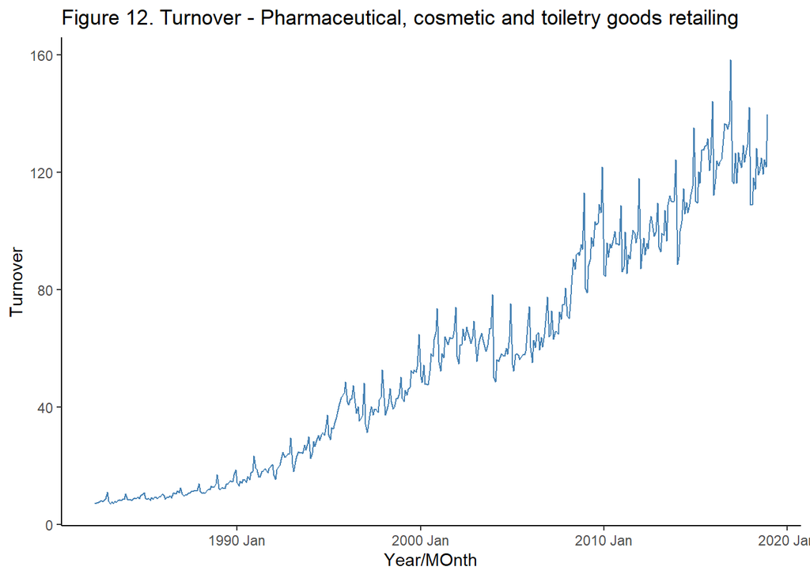

```r
set.seed(124566791)

# load data

series <- aus_retail %>%
  filter(`Series ID` == sample(aus_retail$`Series ID`,1)) #1 specifies number of Series ID groups

# plot row data

series%>%
  autoplot(Turnover , color='steelblue')+
  labs(title = 'Figure 12. Turnover -   Pharmaceutical, cosmetic and toiletry goods retailing', x='Year/MOnth')+
  theme_classic()
```

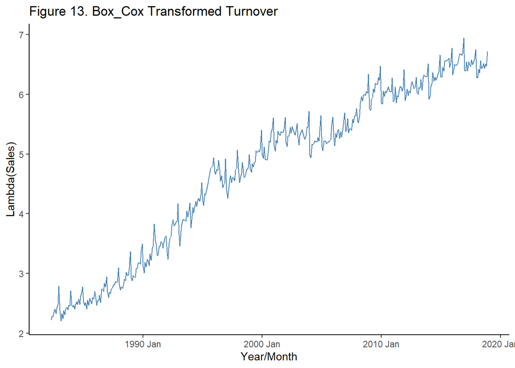

```r
# Estimate lambda - #.118 log()

lambda_turn<-series%>%
  features(Turnover, features=guerrero)%>%
  pull(lambda_guerrero)

# Plot transformed data

series%>%
  autoplot(box_cox(Turnover, lambda_turn), color='steelblue')+
  labs(title = 'Figure 13. Box_Cox Transformed Turnover', x= 'Year/Month', y='Lambda(Sales)')+
  theme_classic()
```

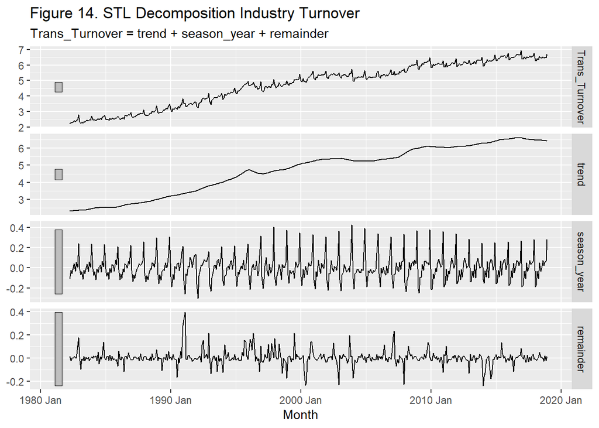

```r
# Decompose to access seasonally adjusted data

library(seasonal)

decomp<-series%>%
  mutate(Trans_Turnover = box_cox(Turnover, lambda_turn))%>%
  model(
    STL(Trans_Turnover ~ trend(window = 13) + season(window=5),
    robust = TRUE))%>%
  components()

decomp%>%
  autoplot()+
  labs(title='Figure 14. STL Decomposition Industry Turnover')
```

```r
# Apply unit root ndiff test

#decomp %>% features(season_adjust, unitroot_nsdiffs) # 0 seasonal diff indicated

decomp %>%
  features(season_adjust, unitroot_ndiffs)%>%
  select(!.model)%>%
  flextable()%>%
  set_caption('Table 5. Unit Root Test: Industry Turnover - Single  Differencing')
```

Table 5. Unit Root Test: Industry Turnover - Single Differencing

| State | Industry | ndiffs |
| --- | --- | --- |
| South Australia | Pharmaceutical, cosmetic and toiletry goods retailing | 1 |

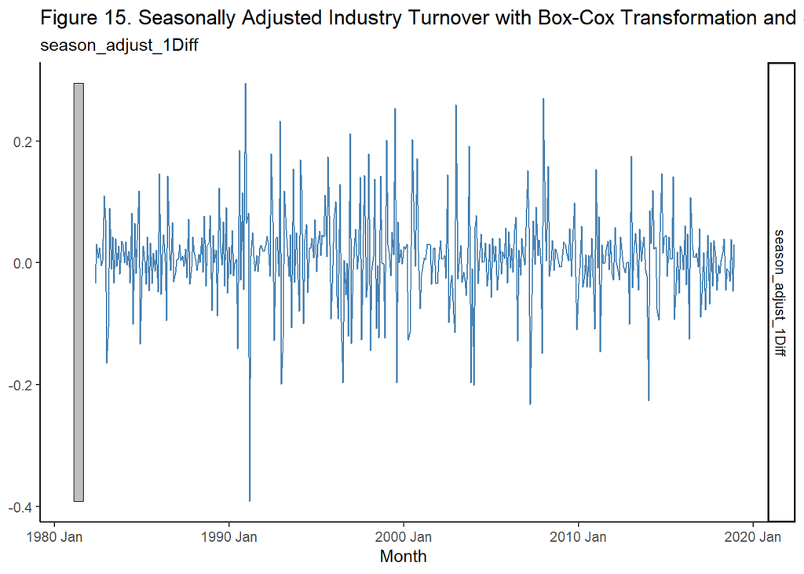

```r
#plot 1st order differencing on seasonally adjusted data

decomp%>%
  mutate(season_adjust_1Diff = difference(season_adjust), 12)%>%
  autoplot(season_adjust_1Diff , color='steelblue')+
  labs(title = 'Figure 15. Seasonally Adjusted Industry Turnover with Box-Cox Transformation and Single Differencing')+
  theme_classic()
```

```r
decomp%>%
  mutate(season_adjust_1Diff = difference(season_adjust), 12)%>%
  features(season_adjust_1Diff, unitroot_kpss)%>%
  select(Industry, kpss_stat, kpss_pvalue)%>%
  flextable()%>%
  set_caption('Table 6. Unit Root Test for Seasonally Adjusted Industry Turnover Data, Log Transformed, Single Differencing')
```

Table 6. Unit Root Test for Seasonally Adjusted Industry Turnover Data, Log Transformed, Single Differencing

| Industry | kpss_stat | kpss_pvalue |
| --- | --- | --- |
| Pharmaceutical, cosmetic and toiletry goods retailing | 0.1905052 | 0.1 |

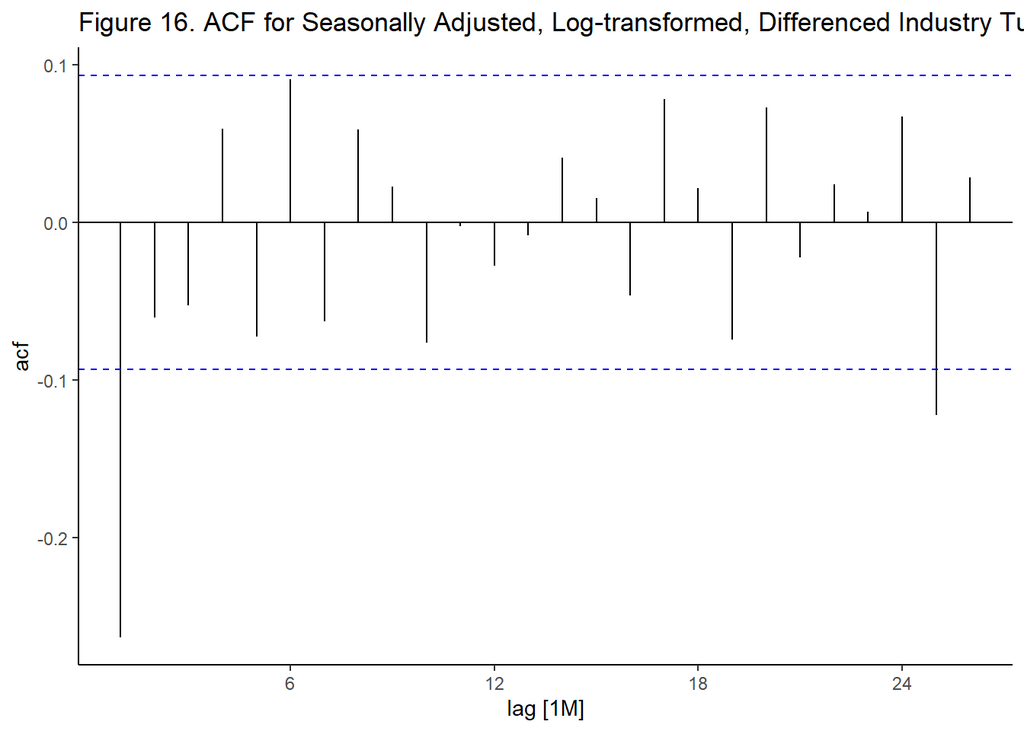

```r
# check acf

decomp_adj <-decomp%>%
  mutate(season_adjust_1Diff = difference(season_adjust), 12)

decomp_adj%>%
  ACF(season_adjust_1Diff)%>%
  autoplot()+
  labs(title = 'Figure 16. ACF for Seasonally Adjusted, Log-transformed, Differenced Industry Turnover Data')+
  theme_classic()
```

# 5 Hyndman: Exercise 9.6

**Simulate and plot some data from simple ARIMA models.**

**Use the following R code to generate data from an AR(1) model with ϕ1=0.6 and σ2=1. The process starts with y1=0.**

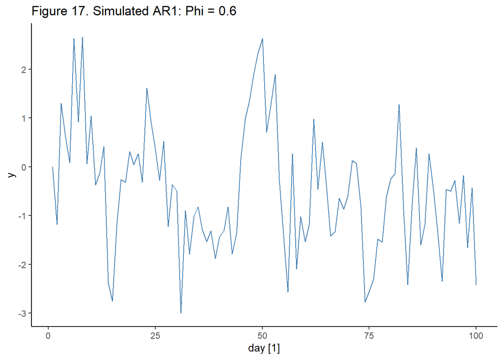

```r
set.seed(4532)

y <- numeric(100)

e <- rnorm(100)

for(i in 2:100)
  y[i] <- 0.6*y[i-1] + e[i]

sim <- tsibble(idx = seq_len(100), y = y, index = idx)

#plot

sim%>%
  rename(day = idx)%>%
  as_tsibble()%>%
  autoplot(color = 'steelblue')+
  labs(title = 'Figure 17. Simulated AR1: Phi = 0.6')+
  theme_classic()
```

**Produce a time plot for the series. How does the plot change as you change ϕ1?**

*Changing phi to ϕ0 results in yt equivalent to white noise.*

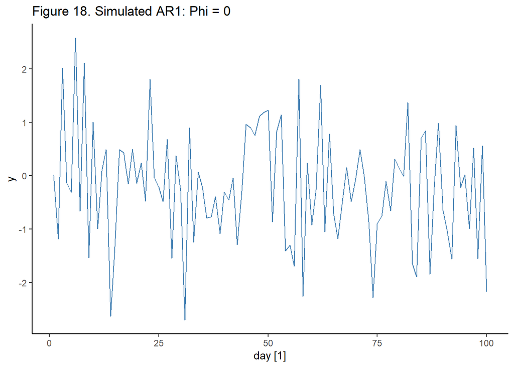

```r
set.seed(2348)

for(j in 2:100)
  y[j] <- 0*y[j-1] + e[j]

sim2 <- tsibble(idx = seq_len(100), y = y, index = idx)

sim2%>%
  rename(day = idx)%>%
  as_tsibble()%>%
  autoplot(color = 'steelblue')+
  labs(title = 'Figure 18. Simulated AR1: Phi = 0')+
  theme_classic()
```

*Changing phi to ϕ1 results in yt equivalent to a random walk, assuming c = 0. Otherwise, yt is includes drift.*

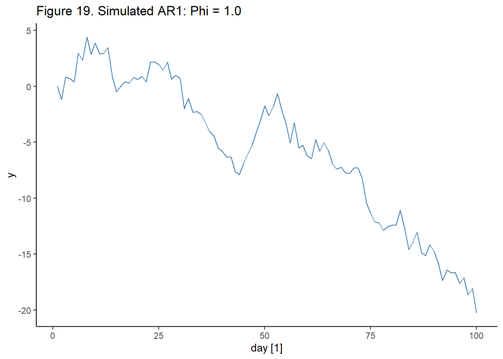

```r
set.seed(543)

for(k in 2:100)
  y[k] <- 1.0*y[k-1] + e[k]

sim3 <- tsibble(idx = seq_len(100), y = y, index = idx)

sim3%>%
  rename(day = idx)%>%
  as_tsibble()%>%
  autoplot(color = 'steelblue')+
  labs(title = 'Figure 19. Simulated AR1: Phi = 1.0')+
  theme_classic()
```

*Changing phi to ϕ-1 causes yt to oscillate around the mean.*